# H4: Final Project

Lavrinenko Olga

2023-03-28

Your final homework assignment will be a test of your skills in an independent project. **IMPORTANT** For any of these projects you have to specify the research goal of your work!!! **Deadline:** 27 March, 23:59 (UTC+3) Send your work **(.Rmd + .html files)** to `nikxianercom@gmail.com`, state your full name as the topic of your letter.

# Var 1: Topic Modelling (Advanced: Sentiment analysis)

```r
library(data.table)
library(ggplot2)
library(readr)
library(tidylo)
library(tidytext)
library(tidyverse)
library(dplyr)
library(stm)
library(stringr)
library(stringi)
library(stopwords)
library(tm)
library(tidyr)
library(igraph)
library(ggraph)
library(lsa)
library(textstem)
library(quanteda)
library(stringr)
library(tidytext)
library(lubridate)
library(radarchart)
```

# Summary

- **Goal of project** is to identify whether texts associated with stress differ from texts in which the stress is not identified, according to their vocabulary, topics and sentiments.
- **About the dataset**: the dataset contains data posted on subreddits related to mental health. This dataset contains various mental health problems shared by people about their life. This dataset is labelled as 0 and 1, where 0 indicates no stress and 1 indicates stress.
- **Key findings**:
1. There is a difference in the dictionary between the categories “stress” and “no stress”: the same bigram can have noticeably different frequency in the categories.
2. There are distinctive bigrams for each of the categories, which allow them to be characterized by meaning.
3. There are topics such as “Abusive relationships”, “Recovery and forward movement”, “Professional psychological treatment”, “Thinking about the problems and solutions”, “Addictions and depression”.
4. “Abusive relationships” and “Thinking about the problems and solutions” are associated with stress according to the evaluation of effects of covariates.
5. “Recovery and forward movement” is associated to category “no stress”.
6. There is a difference between categories “stress” and “no stress” in sentiments.
7. The “stress” category tends to have more negative words, while the “no stress” category tends to have more positive words.
8. The most prevailing sentiments in the “stress” category are “anger”, “anticipation”, “fear” and “sadness”. And in the “no stress” category, sentiments of trust and anticipation prevail.

**1. Find dataset on [Kaggle](https://www.kaggle.com/datasets) or other source**

Data: Human Stress Prediction Source: https://www.kaggle.com/datasets/kreeshrajani/human-stress-prediction

The dataset includes 2838 observations and 7 variables.

```r
setwd('D:/Data Analytics For Politics And Society/Text Mining and Natural Language Processing (3 modul)/HW')
data_stress <- read.csv('stress.csv')
dim(data_stress)
```

```
## [1] 2838    7
```

```r
names(data_stress)
```

```
## [1] "subreddit"        "post_id"          "sentence_range"   "text"
## [5] "label"            "confidence"       "social_timestamp"
```

**2. Look through the data. Describe the collection principles and distinguishing characteristics of the data. Do not forget to investigate variables types. Add summary statistics.**

- subreddit: subreddit is a specific community or forum
- post_id: unique_is
- sentence_range: sentence index
- text: text use for stress detection
- label: 0 and 1 , 0 means no stress and 1 means stress
- confidence: confidence level of person on text
- social_timestamp: data and time in timestamp format

Among these variables, we are only interested in “text” and “label”. Classes of these variables are character for text and should be factor for “label”, because label is just a category in format of number.

```r
names(data_stress)
```

```
## [1] "subreddit"        "post_id"          "sentence_range"   "text"
## [5] "label"            "confidence"       "social_timestamp"
```

```r
class(data_stress$text)
```

```
## [1] "character"
```

```r
class(data_stress$label)
```

```
## [1] "integer"
```

```r
data_stress$label <- as.factor(data_stress$label)
```

```r
data_stress %>% group_by(label) %>% summarize(n = n())
```

```
## # A tibble: 2 × 2
##   label     n
##   <fct> <int>
## 1 0      1350
## 2 1      1488
```

```r
# Number of words per line
words_text <- str_split(data_stress$text, " ")
words_per_line_text <- lapply(words_text, length)
data_stress$length_text <- unlist(words_per_line_text)

# Average number of words
data_stress %>%
  group_by(label)%>%
  summarise(words_text = mean(length_text))%>%
  arrange(-(words_text))
```

```
## # A tibble: 2 × 2
##   label words_text
##   <fct>      <dbl>
## 1 1           89.0
## 2 0           82.3
```

```r
summary(data_stress$length_text)
```

```
##    Min. 1st Qu.  Median    Mean 3rd Qu.    Max.
##    1.00   65.00   81.00   85.84  101.00  310.00
```

```r
data_stress$doc_id <- row_number(data_stress)
```

**3. Clean the data (minimal cleaning, stopwords, lemmatization / stemming, whether using TF-IDF or frequency). Explain your cleaning steps and how they will affect the analysis.**

For the frequency review, I will work with bigrams, because they will give more information about the differences between the two categories.

```r
data_raw <- data_stress %>%
  unnest_tokens(bigram, text, token = "ngrams", n = 2)%>%
  group_by(label)
```

Let’s clean the data and remove stop words.

```r
data_cleaned <- data_raw %>%
  separate(bigram, c("word1", "word2"), sep = " ")

data_cleaned <- subset(data_cleaned, str_length(word1)>3 & str_length(word2)>3)
data_cleaned <- subset(data_cleaned, word1 != "https" & word2 != "https")
data_cleaned <- subset(data_cleaned, word1 != "http" & word2 != "http")

data_cleaned <-  data_cleaned %>%
  filter(
    !word1 %in% stop_words$word,                 # remove stopwords from both words in bi-gram
    !word2 %in% stop_words$word,
    !str_detect(word1, pattern = "[[:digit:]]"), # remove any words with numeric digits
    !str_detect(word2, pattern = "[[:digit:]]"),
    !str_detect(word1, pattern = "[[:punct:]]"), # remove any remaining punctuation
    !str_detect(word2, pattern = "[[:punct:]]"),
    !str_detect(word1, pattern = "(.)\\1{2,}"),  # remove any words with 3 or more repeated letters
    !str_detect(word2, pattern = "(.)\\1{2,}"),
    !str_detect(word1, pattern = "\\b(.)\\b"),   # remove any remaining single letter words
    !str_detect(word1, pattern = "\\b(.)\\b")
    ) %>%
  unite("bigram", c(word1, word2), sep = " ")
```

Next is lemmatization.

```r
library(textstem)
bigram_lemma <- data_cleaned %>%
   separate(bigram, c("word1", "word2"), sep = " ") %>%
  mutate(lemma1 = lemmatize_words(word1),
         lemma2 = lemmatize_words(word2)) %>%
  unite("bigram", c(lemma1, lemma2), sep = " ")
```

And now let’s have a look on frequency lists grouped by stress label. We can notice that there are some bigrams which are repeated in both categories, but they have different frequency, for instance, “mental health” prevails in the category marked as stress-free (n = 49), while “panic attack” prevails in a category “stress”.

Also in the category where there is no stress, bigrams such as “feel free” and “fast forward” are common. And in the category with stress bigrams “anxiety attack”, “abusive relationship” are quite frequent.

```r
bigram_lemma %>%
  filter(label == 1)%>%
  count(bigram) %>%
  arrange(-n) %>%
  head(15)
```

```
## # A tibble: 15 × 3
## # Groups:   label [1]
##    label bigram                   n
##    <fct> <chr>                <int>
##  1 1     panic attack            74
##  2 1     mental health           21
##  3 1     anxiety attack          15
##  4 1     abusive relationship    14
##  5 1     feel safe               13
##  6 1     multiple time           13
##  7 1     sexual abuse            13
##  8 1     health issue            12
##  9 1     domestic violence       11
## 10 1     feel guilty             11
## 11 1     social anxiety          11
## 12 1     story short             11
## 13 1     fall asleep             10
## 14 1     hard time               10
## 15 1     health anxiety          10
```

```r
bigram_lemma %>%
  filter(label == 0)%>%
  count(bigram) %>%
  arrange(-n) %>%
  head(15)
```

```
## # A tibble: 15 × 3
## # Groups:   label [1]
##    label bigram                   n
##    <fct> <chr>                <int>
##  1 0     mental health           49
##  2 0     feel free               19
##  3 0     fast forward            14
##  4 0     fall asleep             13
##  5 0     panic attack            13
##  6 0     social medium           12
##  7 0     abusive relationship    11
##  8 0     survey item             10
##  9 0     bank account             9
## 10 0     feel guilty              9
## 11 0     greatly appreciate       9
## 12 0     spend time               9
## 13 0     start date               9
## 14 0     story short              9
## 15 0     move forward             8
```

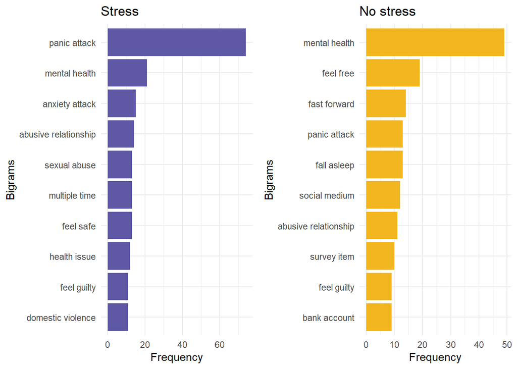

```r
freqlist_stress <- bigram_lemma %>%
    group_by(label)%>%
    count(bigram, sort = T)%>%
    slice(1:10)

plot_stress <- freqlist_stress %>%
  filter(label == "1") %>%
  mutate(bigram = fct_reorder(bigram, n)) %>%

  ggplot(aes(n, bigram))+
    geom_col(fill = "#5E58A5") +
    xlab("Frequency") +
    ylab("Bigrams") +
    ggtitle("Stress") +
    theme_minimal()

plot_nostress <- freqlist_stress %>%
  filter(label == "0") %>%
  mutate(bigram = fct_reorder(bigram, n)) %>%

  ggplot(aes(n, bigram))+
    geom_col(fill = "#F2B620") +
    xlab("Frequency") +
    ylab("Bigrams") +
    ggtitle("No stress") +
    theme_minimal()

library(ggpubr)
ggarrange(plot_stress, plot_nostress,
          ncol = 2, nrow = 1)
```

But it is useful to look at unique bigrams for each of the category. To do this we have to use tf-idf metric and group by label. The higher the value of tf_idf, the more important the bigram for the category of stress (label).

For label “0” - no stress, such bigrams as “survey item”, “private message”, “gift card”, “consent form”, “assess treatment”, “background information” are the most meaningful in case they are not used in the second category. All these bigrams are associated with the implementation of some kind of treatment, maybe sessions with specialists

For label “1” - stress, such bigrams as “health anxiety”, “feel awful”, “heart attack”, “sexually assault”, “chronic pain” are the most meaningful in case they are not used in the first category. And actually, all of them are really associated with mental or physical problems.

```r
data_tf_idf <- bigram_lemma %>%
  count(label, bigram) %>%
  bind_tf_idf(bigram, label, n)%>%
  arrange(-tf_idf)

data_tf_idf %>%
  filter(label == 0) %>%
  head(15)
```

```
## # A tibble: 15 × 6
## # Groups:   label [1]
##    label bigram                     n       tf   idf   tf_idf
##    <fct> <chr>                  <int>    <dbl> <dbl>    <dbl>
##  1 0     survey item               10 0.00159  0.693 0.00110
##  2 0     private message            8 0.00127  0.693 0.000879
##  3 0     gift card                  7 0.00111  0.693 0.000769
##  4 0     consent form               6 0.000951 0.693 0.000659
##  5 0     adult seek                 5 0.000793 0.693 0.000550
##  6 0     assess treatment           5 0.000793 0.693 0.000550
##  7 0     background information     5 0.000793 0.693 0.000550
##  8 0     begin complete             5 0.000793 0.693 0.000550
##  9 0     benefit receive            5 0.000793 0.693 0.000550
## 10 0     bipolar disorder           5 0.000793 0.693 0.000550
## 11 0     click agree                5 0.000793 0.693 0.000550
## 12 0     confidential click         5 0.000793 0.693 0.000550
## 13 0     demographic background     5 0.000793 0.693 0.000550
## 14 0     department research        5 0.000793 0.693 0.000550
## 15 0     form explain               5 0.000793 0.693 0.000550
```

```r
data_tf_idf %>%
  filter(label == 1) %>%
  head(15)
```

```
## # A tibble: 15 × 6
## # Groups:   label [1]
##    label bigram                    n       tf   idf   tf_idf
##    <fct> <chr>                 <int>    <dbl> <dbl>    <dbl>
##  1 1     health anxiety           10 0.00156  0.693 0.00108
##  2 1     feel awful                9 0.00140  0.693 0.000972
##  3 1     heart attack              9 0.00140  0.693 0.000972
##  4 1     sexually assault          7 0.00109  0.693 0.000756
##  5 1     stop think                7 0.00109  0.693 0.000756
##  6 1     chronic pain              6 0.000934 0.693 0.000648
##  7 1     social service            6 0.000934 0.693 0.000648
##  8 1     start scream              6 0.000934 0.693 0.000648
##  9 1     stop cry                  6 0.000934 0.693 0.000648
## 10 1     emotional abuse           5 0.000779 0.693 0.000540
## 11 1     feel sick                 5 0.000779 0.693 0.000540
## 12 1     romantic relationship     5 0.000779 0.693 0.000540
## 13 1     chest pain                4 0.000623 0.693 0.000432
## 14 1     commit suicide            4 0.000623 0.693 0.000432
## 15 1     cope mechanism            4 0.000623 0.693 0.000432
```

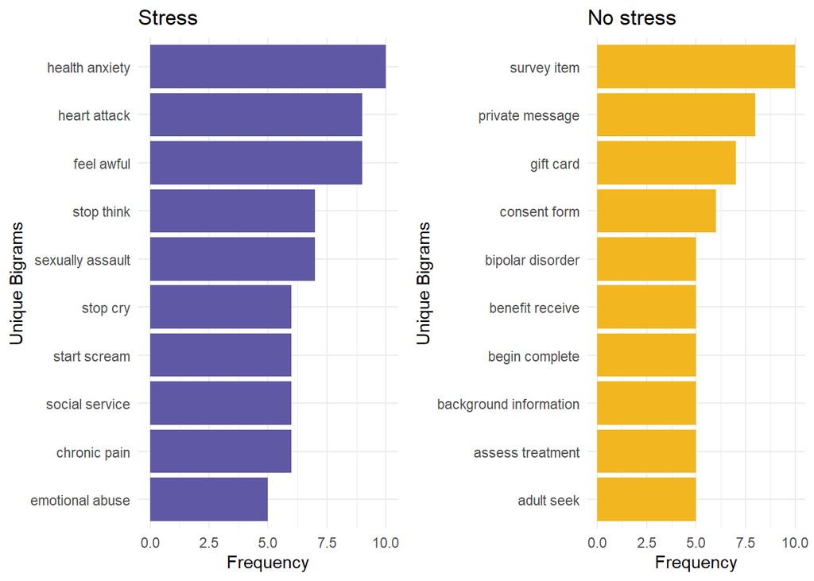

```r
freqlist_stress <- data_tf_idf %>%
    arrange(-tf_idf)%>%
    group_by(label)%>%
    slice(1:10)

plot_stress <- freqlist_stress %>%
  filter(label == "1") %>%
  mutate(bigram = fct_reorder(bigram, n)) %>%

  ggplot(aes(n, bigram))+
    geom_col(fill = "#5E58A5") +
    xlab("Frequency") +
    ylab("Unique Bigrams") +
    ggtitle("Stress") +
    theme_minimal()

plot_nostress <- freqlist_stress %>%
  filter(label == "0") %>%
  mutate(bigram = fct_reorder(bigram, n)) %>%

  ggplot(aes(n, bigram))+
    geom_col(fill = "#F2B620") +
    xlab("Frequency") +
    ylab("Unique Bigrams") +
    ggtitle("No stress") +
    theme_minimal()

library(ggpubr)
ggarrange(plot_stress, plot_nostress,
          ncol = 2, nrow = 1)
```

**4. Choose STM or LDA to perform the topic modelling. Describe why you choose it for the analysis.**

I have chosen the STM because it allows me to evaluate whether a topic belongs to a category (in my case, the categories are stress and no stress) through the generation of a regression table. That is, my interest is not only to identify topics, but also to identify which of them belong to the category of stress, and which are not related to stress. I also will continue to work with bi-grams, because to my mind, they can help to extract well-established expressions and understand each topic better.

```r
data_stress_dfm <- bigram_lemma %>%
    count(doc_id, bigram) %>%
    cast_dfm(doc_id, bigram, n) %>%
    dfm_wordstem(language = "en")

data_stress_meta <- data_stress %>%
    filter(doc_id %in% rownames(data_stress_dfm))

data_stress_meta <- data_stress_meta[c('doc_id', 'label', 'text')]
docvars(data_stress_dfm) <- data_stress_meta

stress_stm <- stm(data_stress_dfm, K = 6, prevalence = ~ label,
                     max.em.its = 5, data = data_stress_meta,
                     init.type = "Spectral")
```

```
## Beginning Spectral Initialization
##   Calculating the gram matrix...
##   Using only 10000 most frequent terms during initialization...
##   Finding anchor words...
##      ......
##   Recovering initialization...
##      .................................................................................................
## Initialization complete.
## ......................................................................................................
## Completed E-Step (0 seconds).
## Completed M-Step.
## Completing Iteration 1 (approx. per word bound = -9.302)
## ......................................................................................................
## Completed E-Step (0 seconds).
## Completed M-Step.
## Completing Iteration 2 (approx. per word bound = -9.063, relative change = 2.564e-02)
## ......................................................................................................
## Completed E-Step (1 seconds).
## Completed M-Step.
## Completing Iteration 3 (approx. per word bound = -8.817, relative change = 2.715e-02)
## ......................................................................................................
## Completed E-Step (0 seconds).
## Completed M-Step.
## Completing Iteration 4 (approx. per word bound = -8.312, relative change = 5.732e-02)
## ......................................................................................................
## Completed E-Step (0 seconds).
## Completed M-Step.
## Model Terminated Before Convergence Reached
```

**Estimate Effects of Covariates**

I got 6 topics: some of them have significant p-value, so we can speak about association of those topics with one of the categories.

So, topic 2 has significant p-value (<0.05) and positive estimate (0.078), so it is more associated with category “stress” then with category “no stress”. In this case “no stress” is a referent category.

Then, topic 3 has significant p-value (<0.05) and negative estimate (-0.124), so it is more associated not with category “stress” but with category “no stress”.

And finally, topic 5 has significant p-value (<0.05) and positive estimate (0.052), so it is more associated with category “stress” then with category “no stress”.

Topic 1, 4 and topic 6 do not have significant p-values.

```r
stress_stm_effect <- estimateEffect(formula = 1:6 ~ label,
                                       stmobj = stress_stm,
                                       metadata = data_stress_meta, uncertainty = "None")
summary(stress_stm_effect)
```

```
##
## Call:
## estimateEffect(formula = 1:6 ~ label, stmobj = stress_stm, metadata = data_stress_meta,
##     uncertainty = "None")
##
##
## Topic 1:
##
## Coefficients:
##              Estimate Std. Error t value Pr(>|t|)
## (Intercept)  0.182987   0.009166  19.964   <2e-16 ***
## label1      -0.018261   0.013035  -1.401    0.161
## ---
## Signif. codes:  0 '***' 0.001 '**' 0.01 '*' 0.05 '.' 0.1 ' ' 1
##
##
## Topic 2:
##
## Coefficients:
##             Estimate Std. Error t value Pr(>|t|)
## (Intercept) 0.108228   0.008497  12.737  < 2e-16 ***
## label1      0.077007   0.012161   6.332 2.83e-10 ***
## ---
## Signif. codes:  0 '***' 0.001 '**' 0.01 '*' 0.05 '.' 0.1 ' ' 1
##
##
## Topic 3:
##
## Coefficients:
##             Estimate Std. Error t value Pr(>|t|)
## (Intercept)  0.23938    0.00960  24.935   <2e-16 ***
## label1      -0.12388    0.01296  -9.557   <2e-16 ***
## ---
## Signif. codes:  0 '***' 0.001 '**' 0.01 '*' 0.05 '.' 0.1 ' ' 1
##
##
## Topic 4:
##
## Coefficients:
##             Estimate Std. Error t value Pr(>|t|)
```

[output cut: 9 more lines]

```
##             Estimate Std. Error t value Pr(>|t|)
## (Intercept)  0.35458    0.01220  29.067  < 2e-16 ***
## label1       0.05188    0.01687   3.075  0.00213 **
## ---
## Signif. codes:  0 '***' 0.001 '**' 0.01 '*' 0.05 '.' 0.1 ' ' 1
##
##
## Topic 6:
##
## Coefficients:
##             Estimate Std. Error t value Pr(>|t|)
## (Intercept) 0.050313   0.004660  10.796   <2e-16 ***
## label1      0.008914   0.006307   1.413    0.158
## ---
## Signif. codes:  0 '***' 0.001 '**' 0.01 '*' 0.05 '.' 0.1 ' ' 1
```

**5. Inspect the TOP-10 words for each topic and guess what they are about**

Topic 1: In this topic, words and phrases, in my opinion, differ quite strongly from each other in direction, there are problems with finances (“bank account”, ” benefit money”), and with abusive relationships (“abusive relationship”, “sexual abus”), and with career difficulties (“company interest”, “experience polit”).

Topic 2: To my mind, the phrases in this topic most of all belong to abusive relationships, family problems, sexual harassment: “abusive relationship”, “domestic viol”, “sexual abus”, “brother heroin”, “heroin addict”, “molest multipl”, “relationship fast”, “burdensome char”. And this topic, according to the analysis from the last part, is really related to stress.

Topic 3: Although there are also some phrases associated with difficulties and serious problems, in general, many words are already lighter and more positive, not gloomy and depressing. And they are already associated with solving problems, moving forward, restoring oneself: “Move forward”, “family hom”, “feel fre”, “free tim”, “return hom”, “greatly appreci”, “fall asleep”, “real lif”. It should be noted that this particular topic, according to the results of the analysis, was previously more associated with the absence of stress.

Topic 4: despite the fact that the words are quite differentiated, it seems to me that in this topic they are more related to professional psychological treatment or counseling (“psychology depart”, “adult seek”, “assess treat”, “therapy sess”, “department research”, “information respond”, “conversion therapi”)

Topic 5: words are associated with psychological well-being, but here, it seems to me, there are many phrases that show attempts to cope with problems and find a solution to one’s difficulties (“spend time”, “stop cri”, “feel comfort”, “stop think”, “life anymor”, “insect memori”, “start liv”, “enjoy lif”)

Topic 6: to my mind, words are associated with various psychological problems, but there are quite a few phrases about addictions, sleep disorders, depression, financial problems (“throw shit”, “relieve depress”, “remain hop”, “doze flip”, “suicide rel” etc)

```r
labelTopics(stress_stm, n = 6)
```

```
## Topic 1 Top Words:
##       Highest Prob: panic attack, multiple tim, abusive relationship, bank account, health anxieti, anxiety attack
##       FREX: social secur, join visit, peanut butt, eventually stop, current studi, completely chang
##       Lift: join visit, abusive stepfath, accidentally agre, actual centrist, autistic quirk, benefit money
##       Score: multiple tim, social secur, minimum wag, join visit, peanut butt, peer support
## Topic 2 Top Words:
##       Highest Prob: panic attack, start dat, abusive relationship, domestic viol, social medium, story short
##       FREX: format failur, mod pleasur, remove survey, student research, university compani, term plan
##       Lift: brother heroin, heroin addict, life hard, recently relaps, molest multipl, past tel
##       Score: abusive relationship, start dat, format failur, panic attack, burdensome char, sexually abus
## Topic 3 Top Words:
##       Highest Prob: panic attack, feel guilti, fall asleep, feel fre, move forward, greatly appreci
##       FREX: real lif, pretty bad, return hom, family hom, cocaine addict, alright alright
##       Lift: family hom, sleep separ, week novemb, woman vot, candidate ahead, include vot
##       Score: feel aw, feel guilti, move forward, family hom, feel fre, free tim
## Topic 4 Top Words:
##       Highest Prob: mental health, health issu, seek treat, survey item, anxiety disord, therapy sess
##       FREX: mental health, adult seek, assess treat, background inform, benefit rec, demographic background
##       Lift: find funni, abuse wis, beat feel, completely invalid, completely snap, conversion therapi
##       Score: mental health, health issu, seek treat, survey item, therapy sess, health treat
## Topic 5 Top Words:
##       Highest Prob: social anxieti, spend tim, make sens, stop cri, similar experi, feel comfort
##       FREX: make sens, time fram, bump bump, start liv, reddit post, entire tim
##       Lift: life anymor, insect memori, stop shak, enjoy lif, kinda expens, natural remedi
##       Score: make sens, stop cri, life anymor, insect memori, start liv, enjoy lif
## Topic 6 Top Words:
##       Highest Prob: panic attack, feel sup, fast forward, homeless peopl, originally post, couple day
##       FREX: feel sup, intentional attempt, nervous system, suicide rel, income hous, throw shit
##       Lift: withdrawal onlin, alleviate symptom, read reinst, relieve depress, remain hop, ssri withdraw
##       Score: feel sup, intentional attempt, nervous system, suicide rel, social aspect, throw shit
```

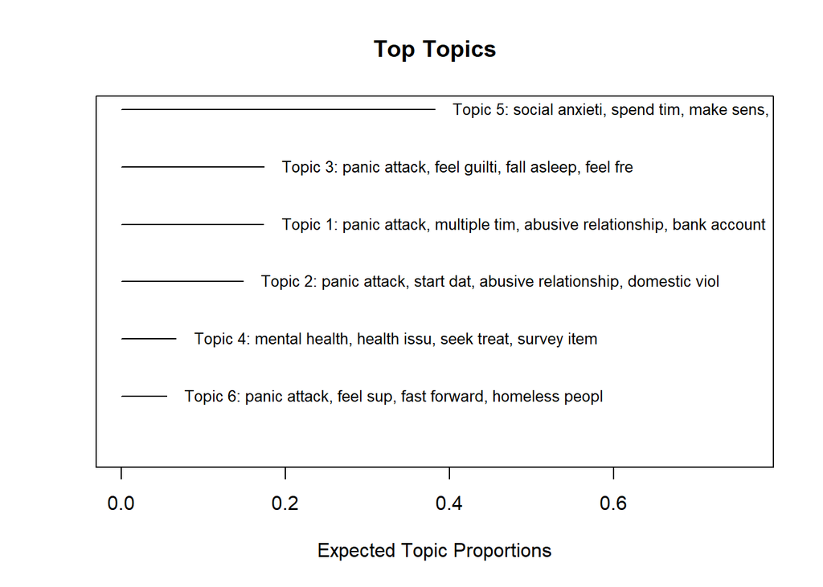

```r
plot(stress_stm, type = "summary", n = 4, text.cex = 0.8)
```

**6. Name the topic and explain why you name it in a certain way**

I have labeled the titles of the topics according to the most likely words, as well as according to the words that received the highest rating, the score for each of the topics. And I also tried above to compare the topic with its meaning.

-Topic 1: Social security -Topic 2: Abusive relationships -Topic 3: Recovery and forward movement -Topic 4: Professional psychological treatment -Topic 5: Thinking about the problems and solutions -Topic 6: Addictions and depression

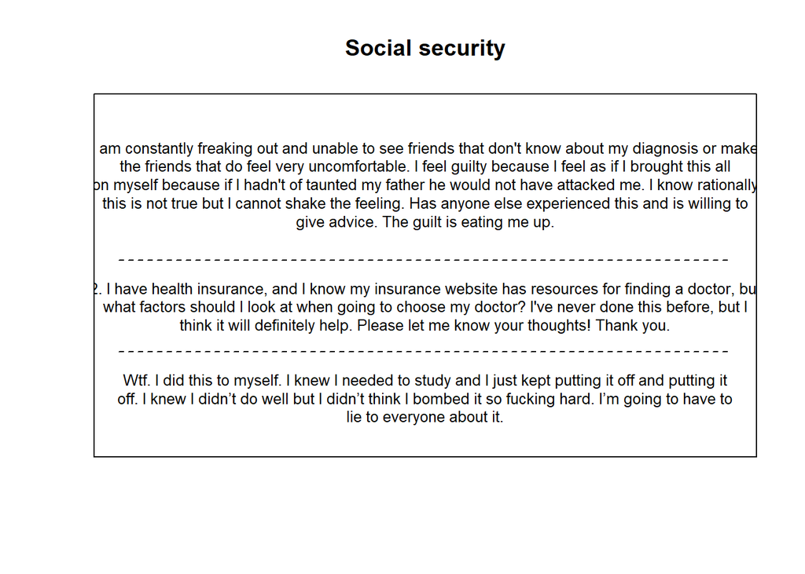

```r
stress_filtered <- data_stress %>%
    filter(doc_id %in% rownames(data_stress_dfm))

social_security <- findThoughts(stress_stm, texts = stress_filtered$text, n = 3, topics = 1)$docs[[1]]
plotQuote(social_security, width = 100, main = "Social security", text.cex = 0.8)
```

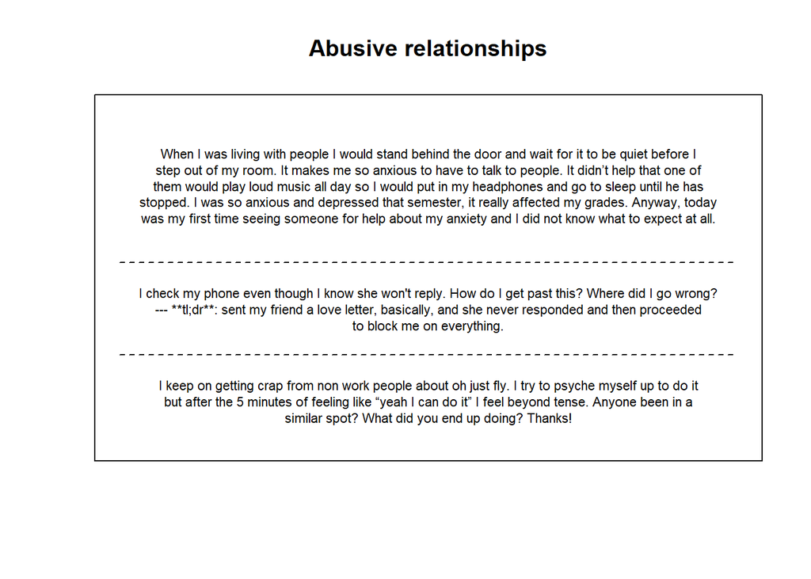

```r
abusive_relationships <- findThoughts(stress_stm, texts = stress_filtered$text, n = 3, topics = 2)$docs[[1]]
plotQuote(abusive_relationships, width = 100, main = "Abusive relationships", text.cex = 0.7)
```

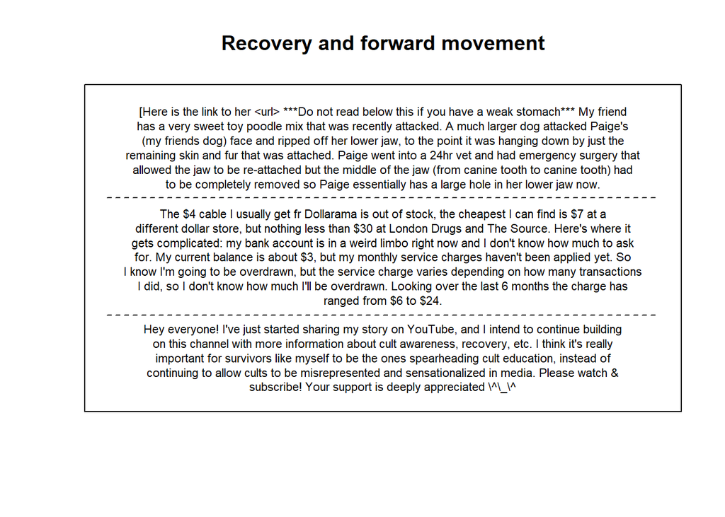

```r
recovery <- findThoughts(stress_stm, texts = stress_filtered$text, n = 3, topics = 3)$docs[[1]]
plotQuote(recovery, width = 100, main = "Recovery and forward movement", text.cex = 0.7)
```

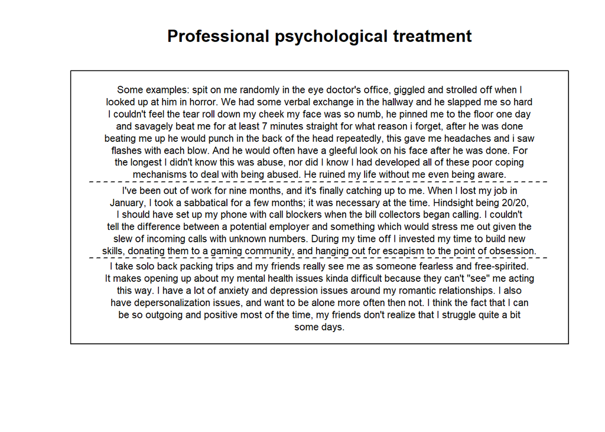

```r
treatment <- findThoughts(stress_stm, texts = stress_filtered$text, n = 3, topics = 4)$docs[[1]]
plotQuote(treatment, width = 100, main = "Professional psychological treatment", text.cex = 0.7)
```

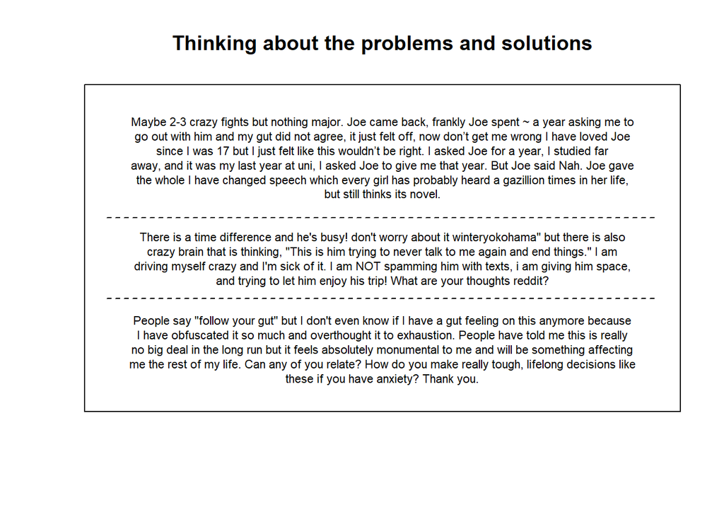

```r
solution <- findThoughts(stress_stm, texts = stress_filtered$text, n = 3, topics = 5)$docs[[1]]
plotQuote(solution, width = 100, main = "Thinking about the problems and solutions", text.cex = 0.7)
```

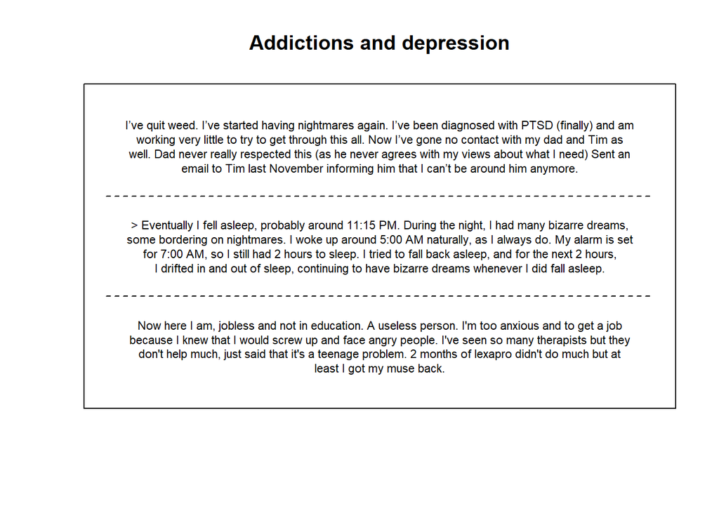

```r
Addictions_and_depression <- findThoughts(stress_stm, texts = stress_filtered$text, n = 3, topics = 6)$docs[[1]]
plotQuote(Addictions_and_depression, width = 100, main = "Addictions and depression", text.cex = 0.7)
```

**7. Write a meaningful conclusion about the topics that are present in the dataset*.**

In general, five topics could be identified in a certain way, one of the topics (the first) consists of phrases of various kinds and therefore it is difficult to determine its name.

So, there are topics such as “Abusive relationships”, “Recovery and forward movement”, “Professional psychological treatment”, “Thinking about the problems and solutions”, “Addictions and depression”. Moreover, “Abusive relationships” and “Thinking about the problems and solutions” are associated with stress according to the evaluation of effects of covariates, while “Recovery and forward movement” is associated to category “no stress”.

This can be hypothetically explained by the fact that the third category includes more positive phrases that do not indicate stress, while the other two categories consist mainly of negative phrases that may be signs of stress.There is no significant p-value for other topics, possibly because although they have negative phrases, they are not associated with stress, but with other psychological or physical diseases.

## **Advanced task**

In addition to the topic modeling you need to perform the sentiment analysis. Please, think about a story you want to tell there, what is your goal, what do you expect to see.

In general, I’m interested in doing a sentiment analysis in terms of the presence or absence of stress. To find out what is the ratio of positive and negative words in these two categories, to identify which sentiments are most characteristic of the categories according to the frequency of words. This will help to distinguish between words and sentiments that can signal whether or not a person is stressed.

Since dictionaries are made up of single words, I will work with tokens and start by clearing the original database

```r
data_stress$text <- str_to_lower(data_stress$text)
data_stress$text <- gsub("[[:digit:]]", "", data_stress$text)
data_stress$text <- gsub("[[:punct:]]", "", data_stress$text)
```

Next let’s tokenize texts by words, lemmatize them and remove stopwords.

```r
data_stress$label <- ifelse(data_stress$label == "1", "stress", "no stress")
data_tok <- data_stress %>%
  unnest_tokens(word, text) %>%
  mutate(lemma = lemmatize_words(word)) %>%
  anti_join(stop_words, by = c("lemma" = "word"))
```

**8. Choose dictionary / dictionaries for your dataset. Provide explanation of your choice.**

I chose these two dictionaries because one of them (bing) will help evaluate the words in the categories in terms of negative and positive, and the other (nrc) will reveal other sentiments that I might have come across before, for example, guilt or anger.

```r
bing <- get_sentiments("bing")
nrc <- get_sentiments("nrc")
```

**9. Compare the sentiment in different categories (for instance, by average sentiment score) and / or compare the sentiments of frequent words in each category. Create at least 3 different visualizations to illustrate your findings.**

**9.1 Most common positive and negative words**

As we can see, negative words are more common than positive ones among the entire text corpus: top-10 negative words have frequent from 100 to 250 times, and two words (“anxiety”, “bad”) are extremely frequent - more than 350 times.

At the same time top-10 positive words have frequent from 50 to 150 times, and one word (“love”) has the highes frequent in category “positive” - almost 300 times (297).

```r
bing_word_counts <- data_tok %>%
  inner_join(get_sentiments("bing")) %>%
  count(lemma, sentiment, sort = TRUE) %>%
  ungroup()

bing_word_counts %>% head (10)
```

```
##      lemma sentiment   n
## 1  anxiety  negative 399
## 2      bad  negative 377
## 3     love  positive 297
## 4    break  negative 226
## 5    issue  negative 185
## 6    abuse  negative 182
## 7     hard  negative 172
## 8     fuck  negative 141
## 9   pretty  positive 133
## 10  attack  negative 132
```

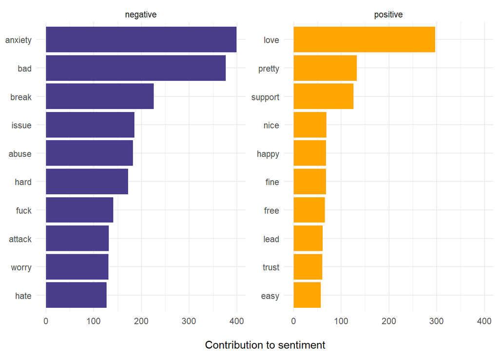

```r
bing_word_counts %>%
  group_by(sentiment) %>%
  slice_max(n, n = 10) %>%
  ungroup() %>%
  mutate(word = reorder(lemma, n)) %>%
  ggplot(aes(n, word, fill = sentiment)) +
  geom_col(show.legend = FALSE) +
  facet_wrap(~sentiment, scales = "free_y") +
  labs(x = "\nContribution to sentiment",
       y = NULL) +
  scale_fill_manual(values=c("#483D8B", "#FFA603"))+
  theme_minimal()
```

**9.2 The number of negative and positive words by label**

Category “no stress” includes 2959 negative words and 4327 positive words, while category “stress” includes 5862 negative words and 4010 positive ones.

If we look at the percentage of negative and positive words for each of the categories, then for “no stress” it is 40,6% against 59,4% (negative and positive), while for the stress category it is vice versa, it is equal to 59, 4% (negative) vs 40,6% (positive). Thus, the stress category tends to have more negative words, while the “no stress” category tends to have more positive words.

```r
s_nrc2 <- data_tok %>%
  inner_join(nrc) %>%
  filter(grepl("positive|negative", sentiment)) %>%
  count(label, sentiment)
s_nrc2
```

```
##       label sentiment    n
## 1 no stress  negative 2959
## 2 no stress  positive 4327
## 3    stress  negative 5862
## 4    stress  positive 4010
```

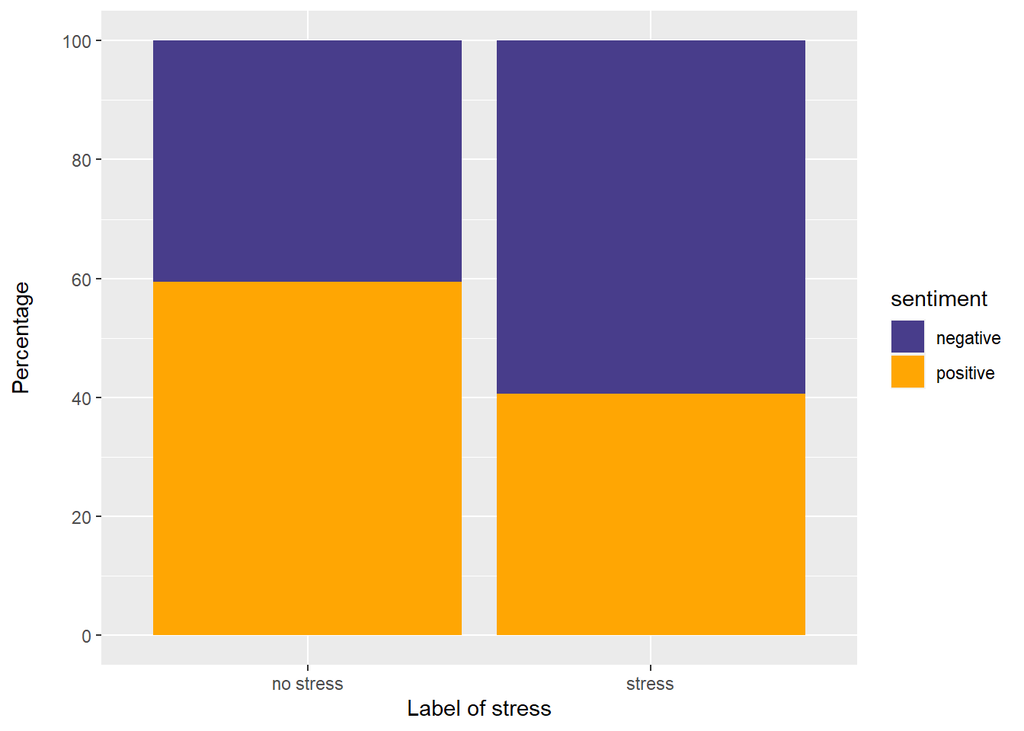

```r
s_nrc2 %>%
  group_by(label) %>%
  mutate(percent_positive = 100 * n / sum(n)) %>%
  ggplot(aes(label, percent_positive, fill = sentiment)) +
  geom_col()+
  scale_fill_manual(values=c("#483D8B", "#FFA603"))+
  xlab("Label of stress")+
  ylab("Percentage\n")+
  scale_y_continuous(breaks = seq(0, 100, by = 20))
```

**9.3 Percentage of different sentiments by label**

And now we can look at the categorization of the number of different sentiments. For the category of stress in relation to the category “no stress”, such sentiments as “anger” (approximately 8% vs 4,5%), “disgust” (approximately 5% vs 2,9%), “fear” (9% vs 5,4%), “sadness” (approximately 9% vs 5%) prevail.

Sentiments like “anticipation” (7,3%) and “surprise” (3%) are about the same in both categories. And such sentiments as “joy” (approximately 5,5% for “no stress” vs 4,5% for “stress”) and “trust” (approximately 7,5% vs 6,8%) are a little more in the category “no stress”.

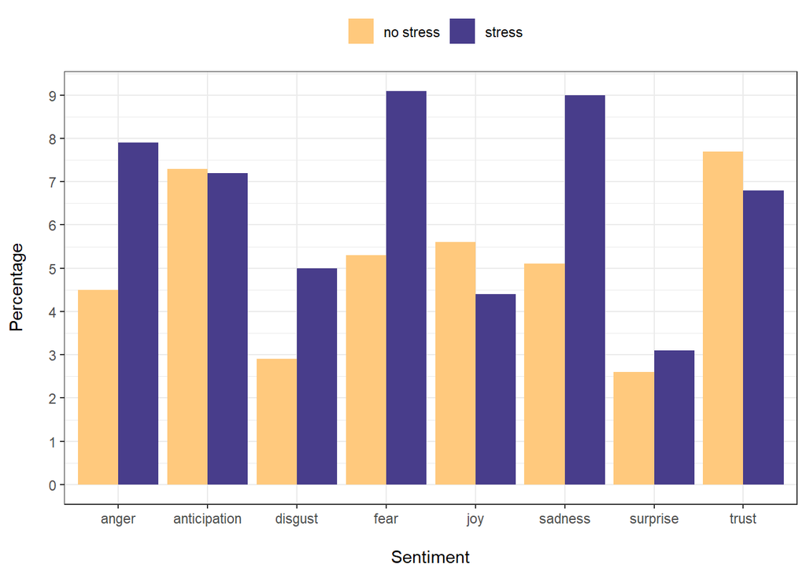

```r
data_sent <- data_tok %>%
  group_by(label) %>%
  mutate(n_words = n()) %>%
  left_join(get_sentiments("nrc")) %>%
  mutate(label = factor(label),
         sentiment = factor(sentiment))

data_sent <- data_sent %>%
  group_by(label, sentiment) %>%
  summarise(sentiment = unique(sentiment),
                   sentiment_freq = n(),
                   n_words = unique(n_words)) %>%
  filter(is.na(sentiment) == F) %>%
  mutate(percentage = round(sentiment_freq/n_words*100, 1))

data_sent %>%
  filter(sentiment != "positive",
         sentiment != "negative") %>%
  ggplot(aes(sentiment, percentage, fill = label)) +
  geom_bar(stat="identity",
           position=position_dodge()) +
  scale_fill_manual(name = "", values=c("#FFC97D", "#483D8B")) +
  theme_bw() +
  theme(legend.position = "top")+
  xlab("\nSentiment")+
  ylab("Percentage\n")+
  scale_y_continuous(breaks = seq(0, 10, by = 1))
```

**9.4 Sentiment scale from anger to joy according to label**

This graph reflects almost the same information as the previous one. That is, we can see the predominance of red bars (negative sentiments) in the category “stress”. At the same time, for the “no stress” category, there is a shift in favor of blue bars (positive sentiment).

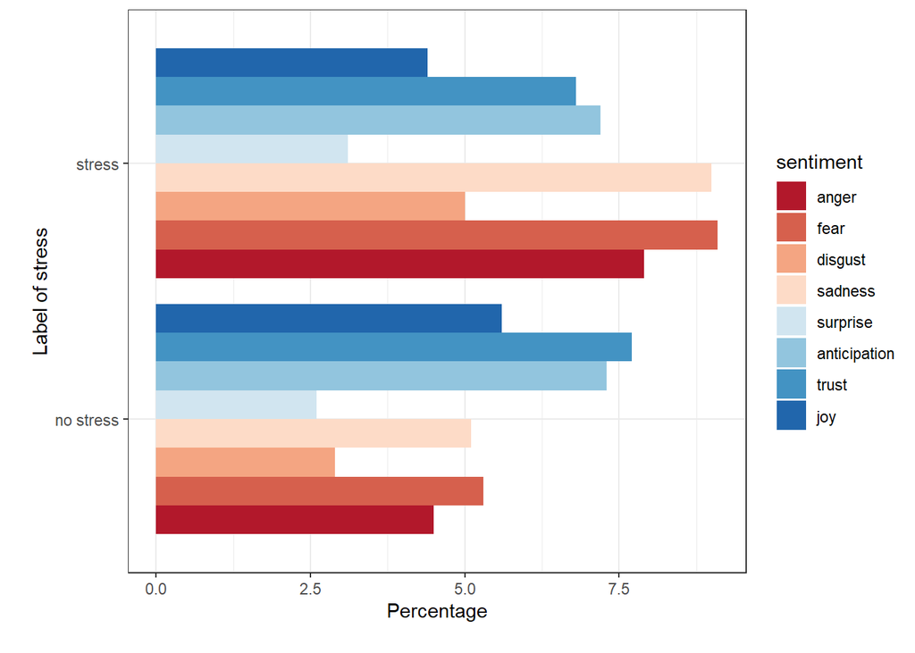

```r
data_sent %>%
  filter(sentiment != "positive",
         sentiment != "negative") %>%
  mutate(sentiment = factor(sentiment,
                            levels = c("anger", "fear", "disgust", "sadness",
                                   "surprise", "anticipation", "trust", "joy"))) %>%
  ggplot(aes(label, percentage, fill = sentiment)) +
  geom_bar(stat="identity", position=position_dodge()) +
  scale_fill_brewer(palette = "RdBu") +
  theme_bw() +
  theme(legend.position = "right") +
  coord_flip()+
  ylab("Percentage\n")+
  xlab("\nLabel of stress")
```

**9.5 Visualization of sentiments for category “stress”**

Radars show the distribution of sentiment for each category. So the most prevailing sentiments in the stress category are anger, anticipation, fear and sadness. And in the “no stress” category, sentiments of trust and anticipation prevail.

```r
stress = data_tok %>% filter(label == "stress")

scores <- stress %>%
  inner_join(nrc, by = c("lemma" = "word")) %>%
  filter(!grepl("positive|negative", sentiment)) %>%
  count(label, sentiment) %>%
  spread(label, n)

chartJSRadar(scores)
```

[interactive chart not shown]

```r
stress = data_tok %>% filter(label == "no stress")

scores <- stress %>%
  inner_join(nrc, by = c("lemma" = "word")) %>%
  filter(!grepl("positive|negative", sentiment)) %>%
  count(label, sentiment) %>%
  spread(label, n)
```

```r
chartJSRadar(scores)
```

[interactive chart not shown]

**10. Create a meaningful conclusion about sentiments between categories**

To sum up, there is the difference between categories “stress” and “no stress” in sentiments. Firstly, the “stress” category tends to have more negative words, while the “no stress” category tends to have more positive words. Secondly, the most prevailing sentiments in the “stress” category are “anger”, “anticipation”, “fear” and “sadness”. And in the “no stress” category, sentiments of trust and anticipation prevail.

This can be explained by the fact that the presence of stress can indeed manifest itself in anger, fear, sadness, a person under stress can express just such emotions. At the same time, a person who is not under stress can also experience these feelings, but most likely to a lesser extent than a person in stress. He or she is likely to have more positive sentiments and most likely they will be expressed during a conversation, since bad emotions, if any, may not greatly depress him, at least not as much as a person experiencing stress.